# Capstone Milestone Report

Michael Crocco

June 12, 2016

## Synopsis

This report details results of downloading, cleaning and exloratory data analysis of data provided by Coursera for the Data Science Capstone Project under guidance by Swiftkey. Three files are provided as corpora for natural language processing intended to lead to a prediction algorithm which, much like Swiftkey’s keyboard application, should be able to predict the next word typed based on typed input. Corpora come from news and blog posts (well structured text) as well as twitter (after all, predictive typing is particulary useful on smartphone keyboards, and need not be gramatically correct).

## Downloading Files and Preliminary Exploration

Text files are provided on the Coursera website: “https://d396qusza40orc.cloudfront.net/dsscapstone/dataset/Coursera-SwiftKey.zip” and are written locally. Additionally, a free list of profane words was found at: “http://www.bannedwordlist.com/lists/swearWords.txt”, and is downloaded as a reference for removing profanity from the corpora.

## Extracting and Summarizing Data

After downloading, the data can be extracted and some basic size information can be gathered.

```r
## GET RAW DATA
fileUrl <- "https://d396qusza40orc.cloudfront.net/dsscapstone/dataset/Coursera-SwiftKey.zip"
fileName <- "Coursera-Swiftkey.zip"
if(!file.exists(fileName)) {
        download.file(fileUrl, destfile = fileName)
}

if(!file.exists('badwords.txt')) {
        download.file('http://www.bannedwordlist.com/lists/swearWords.txt',
                      destfile = 'badwords.txt')
}
dateDownloaded <- date()

if(!file.exists('final/en_US/en_US.blogs.txt')) {
        unzip(fileName, 'final/en_US/en_US.blogs.txt', junkpaths = TRUE)
        unzip(fileName, 'final/en_US/en_US.twitter.txt', junkpaths = TRUE)
        unzip(fileName, 'final/en_US/en_US.news.txt', junkpaths = TRUE)
}

# raw data files
blogs <- readLines('en_US.blogs.txt', skipNul = TRUE)
news <- readLines('en_US.news.txt', skipNul = TRUE)
twitter <- readLines('en_US.twitter.txt', skipNul = TRUE)
```

```
##         No. of Lines Avg. Line Length Min. Length Max. Length Total Words
## Blogs   899288       41.51521         1           6630        37334131
## News    77259        34.22215         1           1031        2643969
## Twitter 2360148      12.86936         1           47          30373583
```

The size and verbosity of the dataset attributes are shown here:

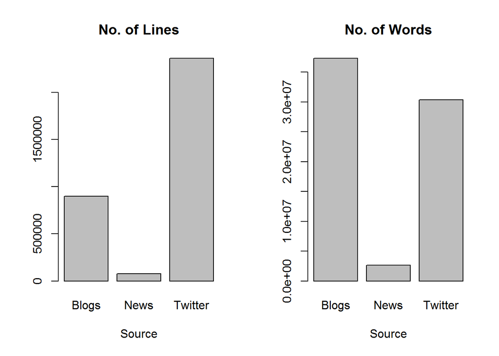

## Cleaning and Analysing Data

The Text Mining (tm) R-package (by Ingo Feinerer, Kurt Hornik, Artifex Software, Inc.) is used extensively to clean and prepare the corpora.

```r
# function to clean corpera
corpusClean = function(corps, minimum){
# Cleans a sample corpus of text for NLP
        library(tm)
        corps = removePunctuation(corps,
                                  preserve_intra_word_dashes = TRUE)
        corps = tolower(corps)
        corps = stripWhitespace(corps)
        corps = removeNumbers(corps)
        corps = removeWords(corps, 'badwords.txt')

}
```

[output not shown]

```
## <<DocumentTermMatrix (documents: 7725, terms: 290)>>
## Non-/sparse entries: 75866/2164384
## Sparsity           : 97%
## Maximal term length: 10
## Weighting          : term frequency (tf)
```

```
## <<DocumentTermMatrix (documents: 7725, terms: 126)>>
## Non-/sparse entries: 28934/944416
## Sparsity           : 97%
## Maximal term length: 8
## Weighting          : term frequency (tf)
```

Once this preparation has been completed, the 20 most common words in each set can be summarized (note: this is the summary of the subset data).

```
## [1] "Blogs"
```

```
##    out   what   will  about    one   they    all   from    not    are
##  10863  10907  11303  11627  12582  14087  14216  14677  17348  19374
##    but   have   this    was   with    you    for   that    and    the
##  20266  21575  25700  27890  28746  29232  36337  45472 108252 184831
```

```
## [1] "News"
```

```
##   one   who  will  they   its   not   has  this   are  have  from   but
##   709   808   821   832   852   864   920   940  1063  1153  1177  1198
##   his   was  said  with   for  that   and   the
##  1200  1788  1894  1997  2615  2634  6751 15312
```

```
## [1] "Twitter"
```

```
##  out what  its  was  not  all  but like love just  are with this have your
##  373  380  383  387  398  399  402  405  414  487  499  541  545  558  608
## that  for  and  you  the
##  738 1281 1397 1729 3030
```

Checking the 20 LEAST common words, it appears the sparsity threshold is reasonable.

```
## [1] "Blogs"
```

```
##       soon     either    several   thinking      share experience
##        953        956        962        973        974        977
##       open     anyone  important     taking      order       says
##        977        978        982        988        998       1004
##    instead      young       play     coming       face  beautiful
##       1012       1013       1014       1018       1021       1022
##     please       else
##       1034       1043
```

```
## [1] "News"
```

```
##   working    sunday      does  american     april     early    enough
##        80        81        83        84        84        84        84
## something   already      area    change   college   getting    monday
##        84        85        85        85        85        86        86
##      name     times     young     along      lead      life
##        86        86        86        87        87        87
```

```
## [1] "Twitter"
```

```
##     even  weekend   coming      fun     look      any     week      him
##       78       80       82       83       84       87       87       89
##  looking      she   always everyone tomorrow     wait    where  morning
##       89       89       90       90       90       90       90       91
##     year  awesome     feel      yes
##       91       92       92       92
```

## Next Steps

### Prediction Algorithm

- Document Term Matrices for quadgrams (groups of four words), trigrams (groups of three), bigrams (groups of two) and unigrams will be created from the greater corpus.
- Once the input has been typed by the user of the application, the input will be searched for starting with the highest order Document Term Matrix, if it isn’t found (and can’t be used for a prediction), the next, lower order Matric will be referenced. If the input can’t be found here, the application will suggest the most common unigram (single word).
- If it’s possible to make the application analyse text input in real-time, it would be possible to suggest autocompletion of the most common words begining with what has been typed. This is not within the scope of the project, but a desireable outcome that will be attempted.